# Spotify Popularity Prediction

```r
knitr::opts_chunk$set(echo = TRUE)
library(tidyverse)
library(purrr)
library(leaps)
library(boot)
set.seed(743)
```

## Task 1

```r
# Set it as current directory
data_dir <- "~/Documents/Spotify Popularity Predictor"

# List all the CSV files in the directory
csv_files <- list.files(paste0(data_dir, "/data"), pattern = ".*csv", full.names = TRUE)

# Read and combine the CSV files using map function and read_csv
combined_data <- map(csv_files, read_csv, show_col_types = FALSE) %>%
  bind_rows()

saveRDS(combined_data, file = "combined_data.rds", compress = FALSE)
```

```r
combined_data <- readRDS("combined_data.rds")
head(combined_data, n = 15)
```

```
## # A tibble: 15 × 20
##    track_id        artists album_name track_name popularity duration_ms explicit
##    <chr>           <chr>   <chr>      <chr>           <dbl>       <dbl> <lgl>
##  1 5SuOikwiRyPMVo… Gen Ho… Comedy     Comedy             73      230666 FALSE
##  2 4qPNDBW1i3p13q… Ben Wo… Ghost (Ac… Ghost - A…         55      149610 FALSE
##  3 1iJBSr7s7jYXzM… Ingrid… To Begin … To Begin …         57      210826 FALSE
##  4 6lfxq3CG4xtTiE… Kina G… Crazy Ric… Can't Hel…         71      201933 FALSE
##  5 5vjLSffimiIP26… Chord … Hold On    Hold On            82      198853 FALSE
##  6 01MVOl9KtVTNfF… Tyrone… Days I Wi… Days I Wi…         58      214240 FALSE
##  7 6Vc5wAMmXdKIAM… A Grea… Is There … Say Somet…         74      229400 FALSE
##  8 1EzrEOXmMH3G43… Jason … We Sing. … I'm Yours          80      242946 FALSE
##  9 0IktbUcnAGrvD0… Jason … We Sing. … Lucky              74      189613 FALSE
## 10 7k9GuJYLp2Azqo… Ross C… Hunger     Hunger             56      205594 FALSE
## 11 4mzP5mHkRvGxdh… Zack T… Episode    Give Me Y…         74      244800 FALSE
## 12 5ivF4eQBqJiVL5… Jason … Love Is a… I Won't G…         69      240165 FALSE
## 13 4ptDJbJl35d7gQ… Dan Be… Solo       Solo               52      198712 FALSE
## 14 0X9MxHR1rTkEHD… Anna H… Bad Liar   Bad Liar           62      248448 FALSE
## 15 4LbWtBkN82ZRhz… Chord … Hold On (… Hold On -…         56      188133 FALSE
## # ℹ 13 more variables: danceability <dbl>, energy <dbl>, key <dbl>,
## #   loudness <dbl>, mode <dbl>, speechiness <dbl>, acousticness <dbl>,
## #   instrumentalness <dbl>, liveness <dbl>, valence <dbl>, tempo <dbl>,
## #   time_signature <dbl>, track_genre <chr>
```

### Quantifying Data Properties

```r
number <- dim(combined_data)
number
```

```
## [1] 114000     20
```

There are 114000 rows and 20 columns

Each row represents a track on Spotify, with details about the track such as `artist`, `album`, `popularity` and other musical attributes like `tempo` and `key`.

```r
unique_genres <- unique(combined_data$track_genre)
number_of_genres <- length(unique_genres)
number_of_genres
```

```
## [1] 114
```

There are 114 genres in this data set.

First we need to remove the songs with zero popularity.

```r
filtered_data <- combined_data %>% filter(popularity > 0)
```

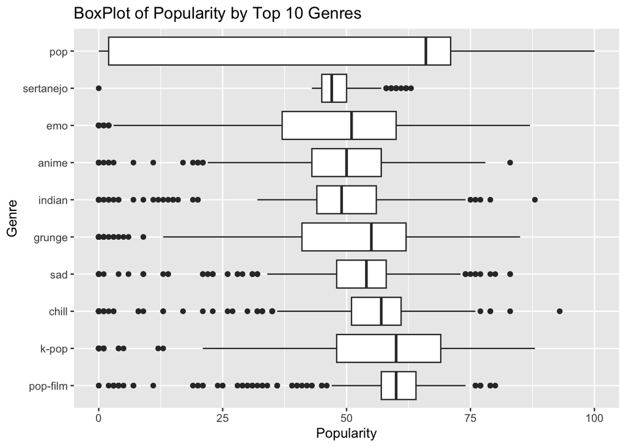

```r
# Find the top N genres by mean popularity
top_10_genres <- combined_data %>%
  group_by(track_genre) %>%
  summarise(mean_popularity = mean(popularity)) %>%
  top_n(10, mean_popularity)

# Filter the data to include only the top 10 genres
top_genres_data <- combined_data %>%
  filter(track_genre %in% top_10_genres$track_genre)

# Create the boxplot
ggplot(top_genres_data, aes(x = popularity, y = reorder(track_genre, -popularity))) +
  geom_boxplot() +
  xlab("Popularity") +
  ylab("Genre") +
  ggtitle("BoxPlot of Popularity by Top 10 Genres")
```

```r
num_rows_removed <- nrow(combined_data) - nrow(filtered_data)
num_rows_removed
```

```
## [1] 16020
```

`16020` Rows of data removed when filtering songs with 0 popularity.

We filtered out the data with 0 popularity as it could represent missing or skewed data. This could affect our prediction model.

```r
colSums(is.na(filtered_data))
```

```
##         track_id          artists       album_name       track_name
##                0                0                0                0
##       popularity      duration_ms         explicit     danceability
##                0                0                0                0
##           energy              key         loudness             mode
##                0                0                0                0
##      speechiness     acousticness instrumentalness         liveness
##                0                0                0                0
##          valence            tempo   time_signature      track_genre
##                0                0                0                0
```

There are no NA values in the `filtered_data`.

Some inappropriate variables for modelling are `track_id` because this is just a unique identifier and does not help with predictions. `album_name` and `track_name` doesn’t really help with predictions either, however, `artists` may help because a song from Taylor Swift for example will be much more popular than a random indie pop band.

`track_genre` is a categorical variable and needs to be encoded for modelling. We can use one-hot encoding to transform these into numerical variables if we want to use it for our model.

Model selection choices: Target Variable - `popularity` will be the target variable.

```r
allyhat <- function(xtrain, ytrain, xtest, lambdas, nvmax = 50) {
  # Number of observations in the training data
  n <- nrow(xtrain)

  # Initialise a matrix to store the predicted responses
  yhat <- matrix(nrow = nrow(xtest), ncol = length(lambdas))

  # Perform backward subset selection on the training data
  search <- regsubsets(xtrain, ytrain, nvmax = nvmax, method = "back")

  # Get a summary of the subset selection result
  summ <- summary(search)

  # Loop over each value of lambda
  for (i in 1:length(lambdas)) {
    # Calculate the penalized MSE for models with different numbers of predictors
    penMSE <- n * log(summ$rss) + lambdas[i] * (1:nvmax)

    # Find the model with the smallest penalized MSE
    best <- which.min(penMSE)

    # Get the coefficients of the best model
    betahat <- coef(search, best)

    # Get the predictors in the best model
    xinmodel <- cbind(1, xtest)[, summ$which[best, ]]

    # Calculate the predicted responses for the test data
    yhat[, i] <- xinmodel %*% betahat
  }

  # Return the matrix of predicted responses
  yhat
}
```

```r
# Create a new column with the selected variables
spotify_data <- filtered_data[, c(
  "danceability",
  "energy",
  "loudness",
  "speechiness",
  "acousticness",
  "instrumentalness",
  "liveness",
  "valence",
  "tempo",
  "time_signature",
  "popularity"
)]

X <- as.matrix(filtered_data[, -c(1:5, 20)])

# Extract the response variable
y <- filtered_data$popularity

set.seed(743)

folds <- sample(rep(1:10, length.out = nrow(X)))

# Define a set of lambda values
lambdas <- c(2, 4, 6, 8, 10, 12)

# Init a matrix to store fitted values
fitted <- matrix(nrow = nrow(X), ncol = length(lambdas))

# Perform cross-validation using the allyhat function
for (k in 1:10) {
  train <- (1:nrow(X))[folds != k]
  test <- (1:nrow(X))[folds == k]
  fitted[test, ] <- allyhat(X[train, ], y[train], X[test, ], lambdas, nvmax = 14)
}

result <- rbind(lambdas, colMeans((y - fitted) ^ 2))
print(result)
```

```
##             [,1]     [,2]     [,3]     [,4]    [,5]     [,6]
## lambdas   2.0000   4.0000   6.0000   8.0000  10.000  12.0000
##         344.1721 344.1721 344.1721 344.1831 344.216 344.2164
```

```r
opt_lambda = 6
```

seems like $\lambda$ = 2,4,6 has the lowest MSPE of 344.1721

```r
search <- regsubsets(X, y, nvmax = 14, method = "backward")
summ <- summary(search)


penMSE <- nrow(X)*log(summ$rss)+ opt_lambda*(1:14)
best <- which.min(penMSE)
betahat <- coef(search, best)
betahat |>
  as_tibble(rownames = "Variable") |>
  rename(Coeff = value) |>
  mutate(Coeff = round(Coeff, 3)) |>
  knitr::kable()
```

| Variable | Coeff |
| --- | --- |
| (Intercept) | 49.516 |
| duration_ms | 0.000 |
| explicit | 4.280 |
| danceability | 7.064 |
| energy | -7.495 |
| loudness | 0.238 |
| mode | -0.656 |
| speechiness | -20.977 |
| acousticness | -1.368 |
| instrumentalness | -11.785 |
| liveness | -2.113 |
| valence | -7.480 |
| tempo | -0.007 |
| time_signature | 0.695 |

Based on this, we can select the model predictors. It seems like `speechiness`, `instrumentalness`, `valence`, `energy`, `dancebility`and `,explicit` all has a relative big impact on the popularity.

Our target variable is still `popularity`.

I used a lambda value of 6 at the end, even though 2, 4 and 6 all shared the same MSPE.

```r
# Fit final model using selected predictors
final_model <- lm(popularity ~ speechiness + instrumentalness + valence + energy + danceability + explicit,
            data = filtered_data)

# Summary of the final model
summary(final_model)
```

```
##
## Call:
## lm(formula = popularity ~ speechiness + instrumentalness + valence +
##     energy + danceability + explicit, data = filtered_data)
##
## Residuals:
##     Min      1Q  Median      3Q     Max
## -49.796 -13.642  -0.023  13.410  58.598
##
## Coefficients:
##                  Estimate Std. Error t value Pr(>|t|)
## (Intercept)       42.7994     0.2604  164.35   <2e-16 ***
## speechiness      -22.9594     0.5743  -39.98   <2e-16 ***
## instrumentalness -12.9822     0.2006  -64.70   <2e-16 ***
## valence           -7.8233     0.2764  -28.30   <2e-16 ***
## energy            -3.2377     0.2485  -13.03   <2e-16 ***
## danceability       9.4622     0.3924   24.11   <2e-16 ***
## explicitTRUE       4.6638     0.2257   20.66   <2e-16 ***
## ---
## Signif. codes:  0 '***' 0.001 '**' 0.01 '*' 0.05 '.' 0.1 ' ' 1
##
## Residual standard error: 18.59 on 97973 degrees of freedom
## Multiple R-squared:  0.06246,    Adjusted R-squared:  0.0624
## F-statistic:  1088 on 6 and 97973 DF,  p-value: < 2.2e-16
```

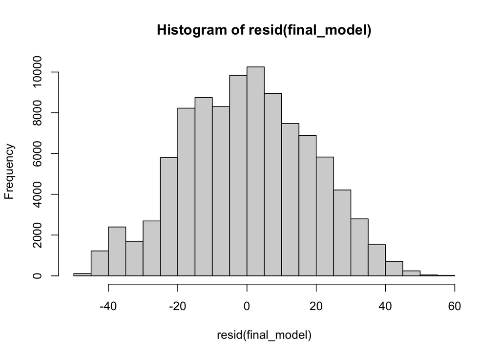

```r
hist(resid(final_model))
```

After fitting the final model with our selected predictors, I ran it through the summary function. All the predictors/coefficients have p-value of <0.05, which means they are all statistically significant.

However, we have a R-squared value of 0.062, which means our model only explains 6.2% of the variations in `popularity`. This means that while the model does capture some underlying pattern in the data, the low R-squared sugggests there are other factors that I haven’t included in this model that contributes to the popularity.

## Testing the prediction with a random song selection

```r
set.seed(743)

# Choose a song from the cleaned dataset
my_song <- filtered_data |>
  slice(614)

# Display the data for the song using kable()
knitr::kable(my_song)
```

| track_id | artists | album_name | track_name | popularity | duration_ms | explicit | danceability | energy | key | loudness | mode | speechiness | acousticness | instrumentalness | liveness | valence | tempo | time_signature | track_genre |
| --- | --- | --- | --- | --- | --- | --- | --- | --- | --- | --- | --- | --- | --- | --- | --- | --- | --- | --- | --- |
| 4Akic5cb5RHJrTdQZY7AfX | Jason Mraz | Know. | No Plans | 46 | 148000 | FALSE | 0.491 | 0.304 | 9 | -9.379 | 1 | 0.0291 | 0.5 | 0 | 0.0975 | 0.459 | 149.288 | 4 | acoustic |

```r
# Prediction function for bootstrapping
pred_func <- function(data, i){
  fit <- lm(popularity ~ speechiness + instrumentalness + valence + energy + danceability + explicit,
            data = data[i,])
  predict(fit, my_song, interval = "none")
}

# Perform bootstrapping with at least 1000 iterations

boots <- boot(filtered_data, pred_func, R = 1000)


# Calculate 95% confidence interval for the prediction
ci <- boots$t0 + c(-1.96, 1.96) * sd(boots$t)
round(ci, 2)
```

```
## [1] 41.98 42.42
```

The confidence interval is 41.98 to 42.42

# References

Maharshi Pandya. (2022). 🎹 Spotify Tracks Dataset [Data set]. Kaggle. https://doi.org/10.34740/KAGGLE/DSV/4372070